# Assig 2 Solutions

Jeff

3/21/2022

# Q1

## (a) (2 marks)

```r
library(mlbench)
library(forcats)
data("HouseVotes84")
hv84 <- data.frame(apply(HouseVotes84, 2, function(v) fct_explicit_na(v, na_level = "NoVote")), stringsAsFactors = TRUE)
head(hv84)
```

|  | Class | V1 | V2 | V3 | V4 | V5 | V6 | V7 | V8 | V9 | V10 | V11 | V12 | V13 | V14 | V15 | V16 |
| --- | --- | --- | --- | --- | --- | --- | --- | --- | --- | --- | --- | --- | --- | --- | --- | --- | --- |
| 1 | republican | n | y | n | y | y | y | n | n | n | y | NoVote | y | y | y | n | y |
| 2 | republican | n | y | n | y | y | y | n | n | n | n | n | y | y | y | n | NoVote |
| 3 | democrat | NoVote | y | y | NoVote | y | y | n | n | n | n | y | n | y | y | n | n |
| 4 | democrat | n | y | y | n | NoVote | y | n | n | n | n | y | n | y | n | n | y |
| 5 | democrat | y | y | y | n | y | y | n | n | n | n | y | NoVote | y | y | y | y |
| 6 | democrat | n | y | y | n | y | y | n | n | n | n | n | n | y | y | y | y |

## (b) (1 mark)

```r
library(cluster)
dists <- daisy(hv84[,-1], metric="gower")
```

## (c) (4 marks)

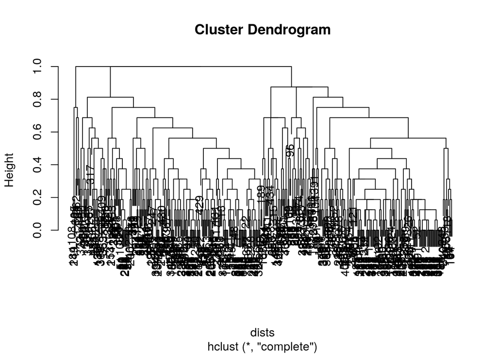

```r
hc1 <- hclust(dists, method="complete")
plot(hc1)
```

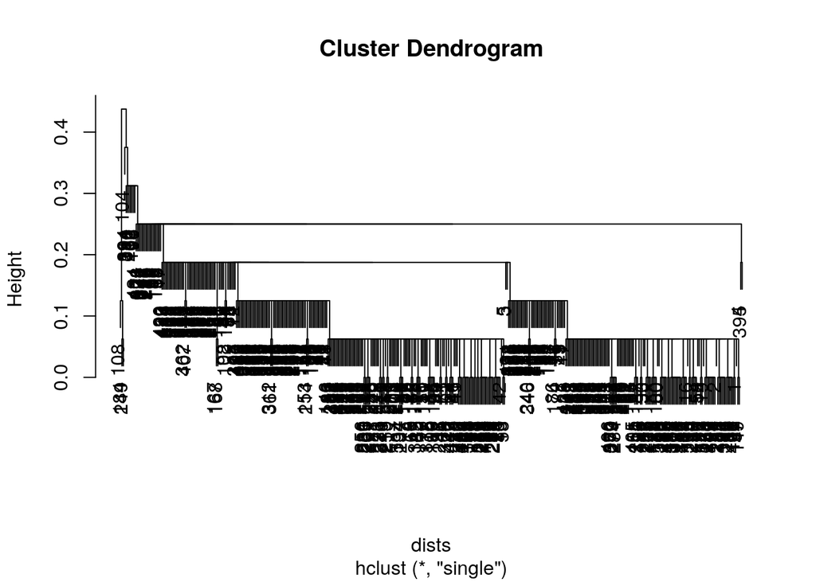

```r
hc2 <- hclust(dists, method="single")
plot(hc2)
```

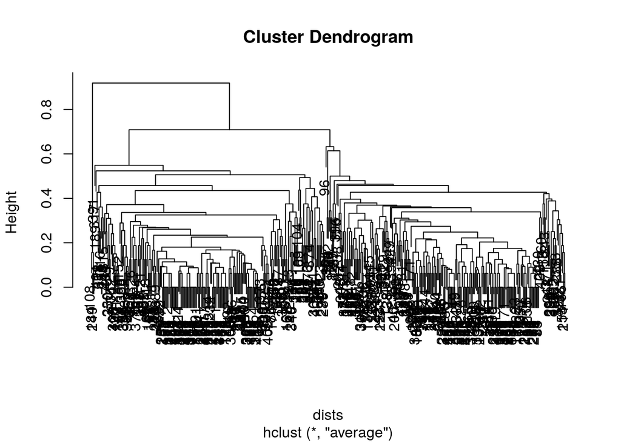

```r
hc3 <- hclust(dists, method="average")
plot(hc3)
```

Complete linkage provides the clearest group structure: 3 groups would be the suggestion from the dendrogram.

```r
table(hv84[,1], cutree(hc1, 3))
```

```
##
##                1   2   3
##   democrat    58 204   5
##   republican 160   5   3
```

## (d) (2 marks)

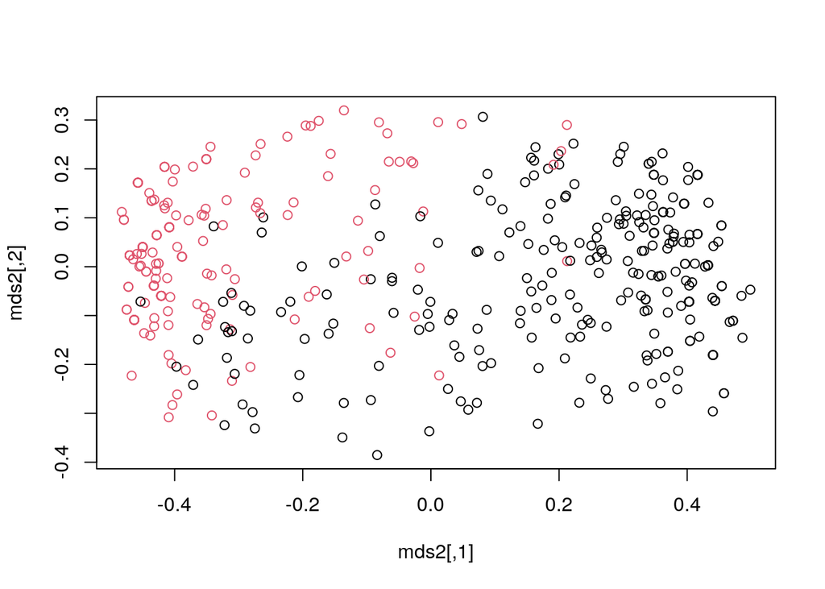

```r
mds2 <- cmdscale(dists, 2)
plot(mds2, col=hv84[,1])
```

## (e) (3 marks)

```r
km2 <- kmeans(mds2, 2, nstart=50)
table(hv84[,1], km2$clus)
```

```
##
##                1   2
##   democrat    42 225
##   republican 159   9
```

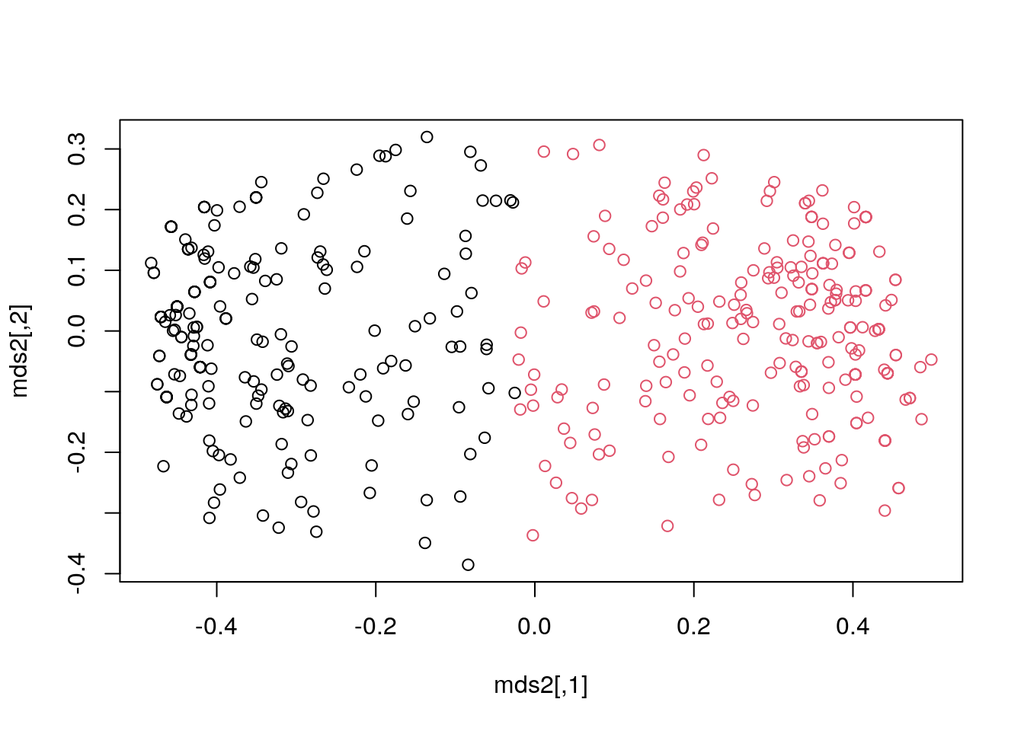

```r
plot(mds2, col=km2$clus)
```

## (f) (3 marks)

```r
library(mclust)
mrun <- Mclust(mds2)
mrun$BIC
```

```
## Bayesian Information Criterion (BIC):
##         EII       VII      EEI      VEI      EVI      VVI      EEE      VEE
## 1 -138.3982 -138.3982 128.6049 128.6049 128.6049 128.6049 122.5295 122.5295
## 2  355.7648  349.7271 352.4105 346.3489 347.4166 368.6731 346.8456 340.8421
## 3  362.9855  400.5381 428.4158 451.7854 423.2005 480.7041 432.5525 454.6219
## 4  386.6359  406.6416 452.1234 474.5390 443.1983 474.0827 454.7219 481.8702
## 5  387.2951  433.2811 463.2730 500.4131 452.4908 495.2303 477.4899 498.8761
## 6  416.4601  431.7960 466.0254 489.7436 451.9888 486.2804 472.8307 483.7543
## 7  409.6636  417.0000 449.9723 470.7878 442.6724 472.7371 458.4763 471.0763
## 8  402.5593  442.4085 431.7587 459.3562 423.8979 453.8031 455.0491 459.1995
## 9  384.4001  448.1724 449.4872 475.8503 416.4475 425.8652 447.6013 470.2834
##        EVE      VVE      EEV      VEV      EVV      VVV
## 1 122.5295 122.5295 122.5295 122.5295 122.5295 122.5295
## 2 341.6965 363.8768 340.8374 346.6227 335.7557 360.1159
## 3 427.5874 478.8831 423.0056 450.5796 417.7866 471.5715
## 4 439.7113 467.4849 433.0711 469.0756 426.2810 457.3049
## 5 463.9331 486.8870 451.7624 469.3496 440.8429 480.5732
## 6 445.2878 479.6194 435.8881 399.7563 440.3431 463.1684
## 7 444.1552 467.6288 436.2342 427.8358 417.3385 439.9679
## 8 429.6832 448.6888 436.3932 415.5953 395.1761 401.6932
## 9 420.2819 408.7210 417.6591 407.7259 374.7703 378.3597
##
## Top 3 models based on the BIC criterion:
##    VEI,5    VEE,5    VVI,5
## 500.4131 498.8761 495.2303
```

Mclust suggests a 5 group solution.

```r
table(hv84[,1], mrun$clas)
```

```
##
##                1   2   3   4   5
##   democrat    26  39 138  63   1
##   republican  45  27   0   4  92
```

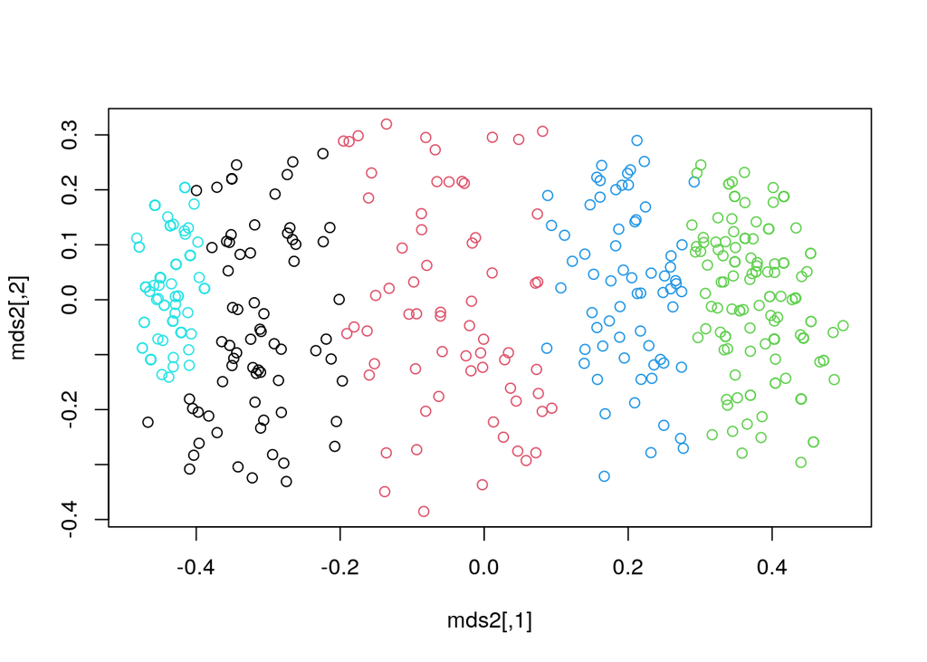

```r
plot(mds2, col=mrun$clas)
```

# Q2

## (a) (3 marks)

```r
q1 <- factanal(covmat=ability.cov$cov, factors=1, rotation="none", n.obs=112)
q1
```

```
##
## Call:
## factanal(factors = 1, covmat = ability.cov$cov, n.obs = 112,     rotation = "none")
##
## Uniquenesses:
## general picture  blocks    maze reading   vocab
##   0.535   0.853   0.748   0.910   0.232   0.280
##
## Loadings:
##         Factor1
## general 0.682
## picture 0.384
## blocks  0.502
## maze    0.300
## reading 0.877
## vocab   0.849
##
##                Factor1
## SS loadings      2.443
## Proportion Var   0.407
##
## Test of the hypothesis that 1 factor is sufficient.
## The chi square statistic is 75.18 on 9 degrees of freedom.
## The p-value is 1.46e-12
```

The output indicates that there is evidence to reject the null hypothesis (namely, that 1 factor is sufficient to explain the observed covariance matrix), hence this is not a suitable model.

## (b) (2 marks)

```r
q1cor <- factanal(covmat=cov2cor(ability.cov$cov), factors=1, rotation="none", n.obs=112)
q1cor
```

```
##
## Call:
## factanal(factors = 1, covmat = cov2cor(ability.cov$cov), n.obs = 112,     rotation = "none")
##
## Uniquenesses:
## general picture  blocks    maze reading   vocab
##   0.535   0.853   0.748   0.910   0.232   0.280
##
## Loadings:
##         Factor1
## general 0.682
## picture 0.384
## blocks  0.502
## maze    0.300
## reading 0.877
## vocab   0.849
##
##                Factor1
## SS loadings      2.443
## Proportion Var   0.407
##
## Test of the hypothesis that 1 factor is sufficient.
## The chi square statistic is 75.18 on 9 degrees of freedom.
## The p-value is 1.46e-12
```

There are no differences between running FA on a covariance matrix versus a correlation matrix…FA is scale invariant.

## (c) (4 marks)

```r
q2 <- factanal(covmat=ability.cov$cov, factors=2, rotation="none", n.obs=112)
q2
```

```
##
## Call:
## factanal(factors = 2, covmat = ability.cov$cov, n.obs = 112,     rotation = "none")
##
## Uniquenesses:
## general picture  blocks    maze reading   vocab
##   0.455   0.589   0.218   0.769   0.052   0.334
##
## Loadings:
##         Factor1 Factor2
## general  0.648   0.354
## picture  0.347   0.538
## blocks   0.471   0.748
## maze     0.253   0.408
## reading  0.964  -0.135
## vocab    0.815
##
##                Factor1 Factor2
## SS loadings      2.420   1.162
## Proportion Var   0.403   0.194
## Cumulative Var   0.403   0.597
##
## Test of the hypothesis that 2 factors are sufficient.
## The chi square statistic is 6.11 on 4 degrees of freedom.
## The p-value is 0.191
```

The output suggests there is not enough evidence to reject the assumption that 2 factors is sufficient.

The first factor loads heavily on reading and vocabulary, and moderately on general intelligence. This factor perhaps measures language comprehension.

The second factor loads heavily on picture and blocks, and then moderately on maze and general. This factor perhaps measures spatial reasoning.

## (d) (4 marks)

```r
q2vm <- factanal(covmat=ability.cov$cov, factors=2, rotation="varimax", n.obs=112)
q2vm
```

```
##
## Call:
## factanal(factors = 2, covmat = ability.cov$cov, n.obs = 112,     rotation = "varimax")
##
## Uniquenesses:
## general picture  blocks    maze reading   vocab
##   0.455   0.589   0.218   0.769   0.052   0.334
##
## Loadings:
##         Factor1 Factor2
## general 0.499   0.543
## picture 0.156   0.622
## blocks  0.206   0.860
## maze    0.109   0.468
## reading 0.956   0.182
## vocab   0.785   0.225
##
##                Factor1 Factor2
## SS loadings      1.858   1.724
## Proportion Var   0.310   0.287
## Cumulative Var   0.310   0.597
##
## Test of the hypothesis that 2 factors are sufficient.
## The chi square statistic is 6.11 on 4 degrees of freedom.
## The p-value is 0.191
```

The uniqueness values have not changed, nor the cumulative variation for the total number of factors or the measures of fit at the bottom of the output.

The first factor is more clearly loading heavily on reading and vocab versus picture/blocks/maze (all of which are loading substantially lower). General intelligence loads almost equally on both factors. The second factor loads heavily on picture and blocks and moderately on maze. The interpretations from before (factor 1 = “reading comprehension”, factor 2 = “spatial reasoning”) still make sense, but are more clearly showing on these loadings — thus the interpretation is easier.

## (e) (3 marks)

```r
q2pm <- factanal(covmat=ability.cov$cov, factors=2, rotation="promax", n.obs=112)
q2pm
```

```
##
## Call:
## factanal(factors = 2, covmat = ability.cov$cov, n.obs = 112,     rotation = "promax")
##
## Uniquenesses:
## general picture  blocks    maze reading   vocab
##   0.455   0.589   0.218   0.769   0.052   0.334
##
## Loadings:
##         Factor1 Factor2
## general  0.364   0.470
## picture          0.671
## blocks           0.932
## maze             0.508
## reading  1.023
## vocab    0.811
##
##                Factor1 Factor2
## SS loadings      1.853   1.807
## Proportion Var   0.309   0.301
## Cumulative Var   0.309   0.610
##
## Factor Correlations:
##         Factor1 Factor2
## Factor1   1.000   0.557
## Factor2   0.557   1.000
##
## Test of the hypothesis that 2 factors are sufficient.
## The chi square statistic is 6.11 on 4 degrees of freedom.
## The p-value is 0.191
```

Added to the output is a correlation matrix for the factors because we have relaxed the assumption of orthogonality for the factors.

With the promax rotation, we’re seeing even clearer versions of our earlier interpretations. For factor 1, picture/blocks/maze all load below the threshold for R to even report them, while reading and vocab load extremely high, and general loads moderately. For factor 2, reading/vocab load below the threshold while maze/general/picture load moderately and blocks loads heavily.

# Q3

```r
###There will be substantial variety in read-in code
###...here's my solution...
#####Get images
to.read = file("~/Downloads/t10k-images-idx3-ubyte", "rb")
readBin(to.read, integer(), n=4, endian="big")
```

```
## [1]  2051 10000    28    28
```

```r
####Build an image array (like the pain data)
imarr <- array(0, dim=c(28,28,10000))
for(i in 1:10000){
  imarr[,,i] <- matrix(readBin(to.read,integer(), size=1, n=28*28, endian="big", signed="F"),28,28)[,28:1]
}
close(to.read)
####Build a flattened image matrix
immat <- t(apply(imarr, 3, as.vector))


####Get Labels
lab.read <- file("~/Downloads/t10k-labels-idx1-ubyte", "rb")
readBin(lab.read, 'integer', n = 1, size = 4, endian = 'big')
```

```
## [1] 2049
```

```r
n = readBin(lab.read, 'integer', n = 1, size = 4, endian = 'big')
labls = readBin(lab.read, 'integer', n = n, size = 1, signed = FALSE)
close(lab.read)
```

## (a) (3 marks)

[figure not shown]

```r
par(mfrow=c(5,5), omi=c(0,0,0,0), mai=c(0.1,0.1,0.1,0.1))
for(i in 1:25) image(imarr[,,i], col=gray((0:32)/32))
```

## (b) (3 marks)

```r
immat <- t(apply(imarr, 3, function(v) as.vector(t(v))))
pcdig <- prcomp(immat) #note the lack of scale
```

```r
ncol(pcdig$rotation)
```

```
## [1] 784
```

Number of principal components in this case is equal to the total number of pixels (variables/predictors in our standard terminology), 784.

## (c) (4 marks)

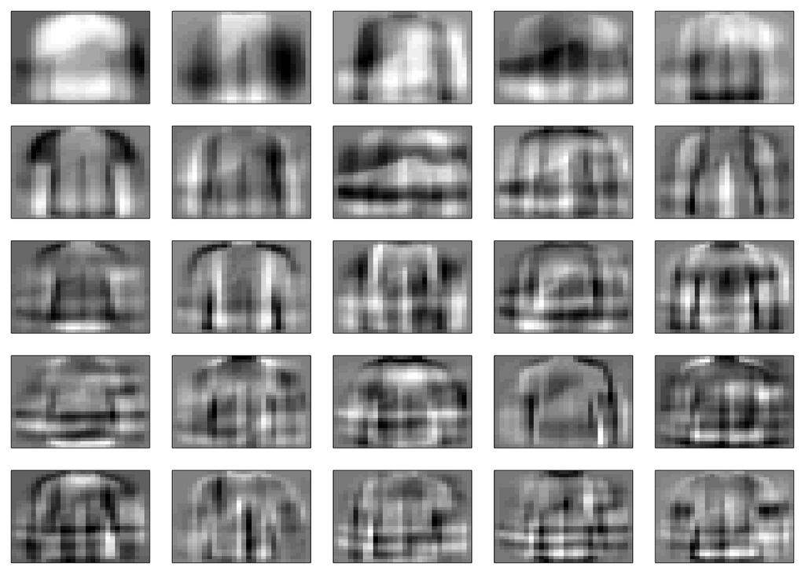

```r
par(mfrow=c(5,5), omi=c(0,0,0,0), mai=c(0.1,0.1,0.1,0.1))
for(i in 1:25){
  image(t(matrix(pcdig$rotation[,i], 28, 28)), col=gray((0:32)/32), xaxt="n", yaxt="n")
}
```

```r
sum((pcdig$sdev^2)[1:25])/sum(pcdig$sdev^2)
```

```
## [1] 0.8045961
```

## (d) (4 marks)

[figure not shown]

```r
reconst <- (t(pcdig$rotation[,1:25] %*% t(pcdig$x[,1:25])))
reconst <- scale(reconst, center=-pcdig$center, scale=FALSE)
par(mfrow=c(5,4), omi=c(0,0,0,0), mai=c(0.1,0.1,0.1,0.1))
for(i in 1:10){
  image(t(matrix(reconst[i,], 28, 28)), col=gray((0:32)/32), xaxt="n", yaxt="n")
  image(imarr[,,i], col=gray((0:32)/32), xaxt="n", yaxt="n")
}
```

## (e) (3 marks)

Here are the commands that I used to create `fnmfres.Rdata`…students are not required to have shown/run this part.

```r
#might have taken up to 25 minutes...
###NMF work
#x: the non-negative data (if any negatives exist, the whole data is shifted)
#q: the number of factors
#eps: convergence criteria (lack of progress on sum squared error)
#maxit: convergence criteria (max iteration when lack of progress not met)
#w: n by q loadings on factors (amount of chemical/molecule/etc)
#h: q by p observed factors (basis chemical/molecule/etc spectra)
#By default (when w, h NULL) both w and h are initialized randomly
nmf <- function(x, q, eps=0.0000001, maxit=2000, w=NULL, h=NULL){
  n <- nrow(x)
  p <- ncol(x)
  if(any(x<0)){x <- as.matrix(x)+abs(min(x))}
  else{x <- as.matrix(x)}
  if(is.null(w)){
    w <- matrix(runif(n*q, min(x), max(x)), n, q)
  }
  if(is.null(h)){
    h <- matrix(runif(p*q, min(x), max(x)), q, p)
  }
  ed <- sum((x-w%*%h)^2)
  conv <- FALSE
  ctr <- 1
  while(!conv){
    ctr <- ctr+1
    h <- h * (t(w) %*% x) / (t(w) %*% w %*% h)
    w <- w * (x %*% t(h)) / (w %*% h %*% t(h))
    h[is.nan(h)] <- 0
    w[is.nan(w)] <- 0
    wh <- w%*%h
    ed[ctr] <- sum((x-wh)^2)
    if((ed[ctr-1]-ed[ctr] < eps)|(ctr==maxit)){
      conv <- TRUE
    }
  }
  list(ed=ed, w=w, h=h, x=x)
}
set.seed(5213541)
test <- nmf(immat+0.01, 25, maxit=600)
```

If they implemented their own version of the above, it’s likely the bases will differ at least in ordering!

Students are expected to have run/shown something along these lines…

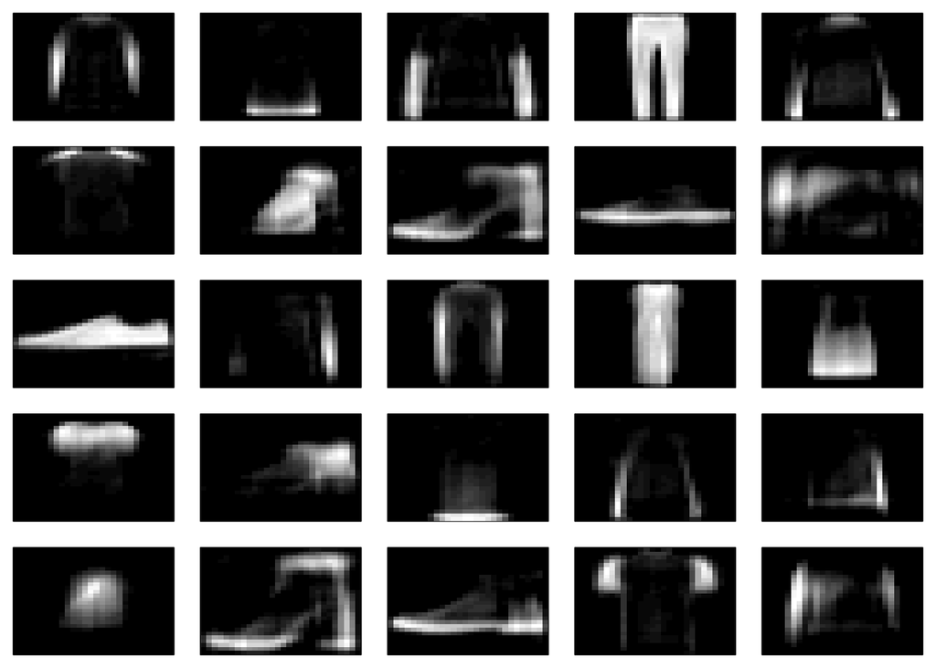

```r
load("~/Downloads/fnmfres.Rdata")
par(mfrow=c(5,5), omi=c(0,0,0,0), mai=c(0.1,0.1,0.1,0.1))
for(i in 1:25){
  image((matrix(fnmfres$h[i,], 28, 28)), col=gray((0:32)/32), xaxt="n", yaxt="n")
}
```

These bases are made up much more of what could be thought of individual elements of fashion items. We can likely pick out several bases and give them a distinct name like “long sleeves” or “high heel boot”. In contrast, the eigenvectors looked more like layers of items within each principal component. For example, the first principal component looks like a bright long sleeve t-shirt with a dark sneaker overlaid on top of it. As we get further into the eigenvectors, they are less and less interpretable.

Note for students: the original MNIST handwritten digits data set also illustrates this type of result. The eigenvectors look like strange “warping” images that vaguely resemble bits and pieces of a digit overlaid on top of one another, while the NMF results look like individual “pen strokes” necessary to draw a number. It is both a constraint (only additive building allowed) and a lack of constraint (correlation among bases permitted) in NMF that lends itself to finding bases like this. Bringing it back to our fashion example, you can easily see that the bases showing “pieces” of the fashion images have to be correlated to some extent. If I score high on basis 1 (lower part of long sleeves), then I’ll probably score highly on something like basis 16 (upper collar and short sleeves of a shirt) and score very close to 0 on basis 11 (sneaker). In PCA the components have to be orthogonal/uncorrelated, in NMF they do not.

## (f) (3 marks)

[figure not shown]

```r
nmfrec <- fnmfres$w %*% fnmfres$h
par(mfrow=c(5,4), omi=c(0,0,0,0), mai=c(0.1,0.1,0.1,0.1))
for(i in 1:10){
  image(matrix(nmfrec[i,], 28, 28), col=gray((0:32)/32), xaxt="n", yaxt="n")
  image(imarr[,,i], col=gray((0:32)/32), xaxt="n", yaxt="n")
}
```

## (g) (2 marks)

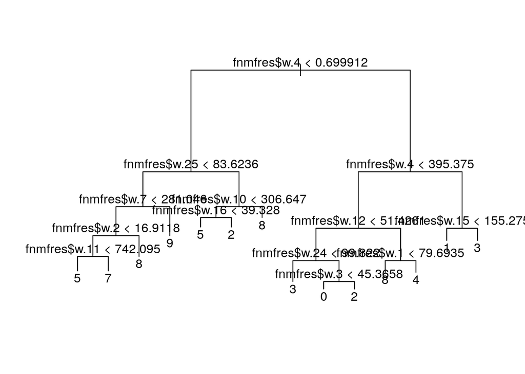

```r
library(tree)
par(mfrow=c(1,1))
treefit <- tree(factor(labls)~fnmfres$w)
plot(treefit)
text(treefit)
```

## (h) (3 marks)

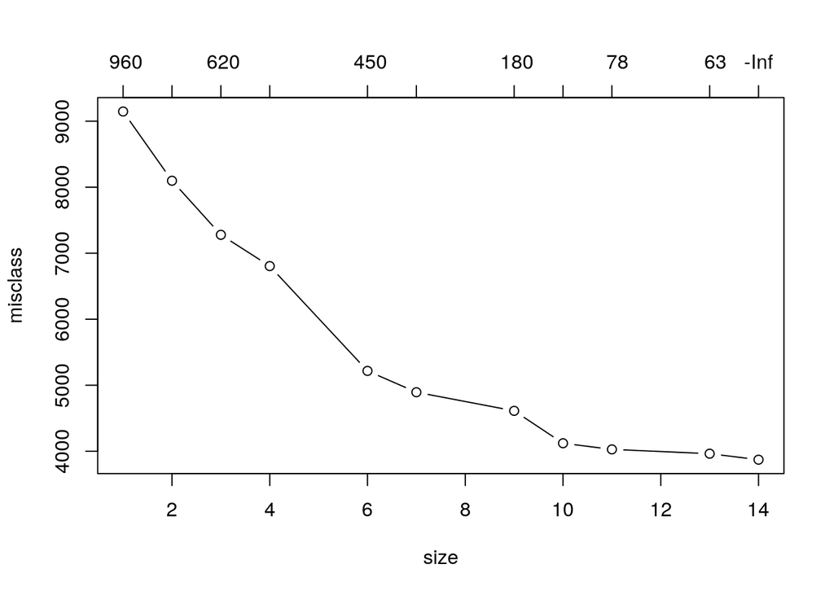

```r
set.seed(53113)
cvfit <- cv.tree(treefit, FUN=prune.misclass)
plot(cvfit, type="b")
```

```r
min(cvfit$dev)/10000
```

```
## [1] 0.3872
```

None of the nodes are suggested to be removed (by my commands and random seed, at least), and the misclassification rate is expected to be around 0.39 according to this run of cross-validation.